# 第1章 一変量データの記述

## 1.4 一変量データの扱い方

### Excelファイル読み込み

```r
library(openxlsx)
sampledata <- read.xlsx('sampledata.xlsx', sheet = 1)
head(sampledata, 5)
```

```
##   math phys
## 1   90   80
## 2   65   65
## 3   60   55
## 4   75   65
## 5   50   75
```

### mathデータの抽出

```r
math <- sampledata$math
length(math)
```

```
## [1] 146
```

### mathデータの確認

```r
math
```

```
##   [1]  90  65  60  75  50  60  25  35  85 100  45  95  80  80  95  55  55  65
##  [19]  50  65  40  85  70  65  65  15  65  75  60  75  25  65  55  40  70  60
##  [37]  60  35  75  45  60  55  75  75  90  35  20  90 100  65  15  80  80  85
##  [55]  25  10  95  45  55  80  80  40  90  95  90  70  80  25  65  30  60  25
##  [73]  35  20  70 100  50  60  50  90  65  45  35  50  85  30  50  70  85  85
##  [91]  75  80  40  60  70  80  95  50  40  25  60  35  30  45  35  70  75  55
## [109]  40 100  50  55  90  95  60  70  80  70  45  55  75  45  65  30  25  85
## [127]  90  90  60  85  20  75  70  75  50  90  60  15  90  75  70  35  95  60
## [145]  45  55
```

```r
math[14]
```

```
## [1] 80
```

### ヒストグラムの表示

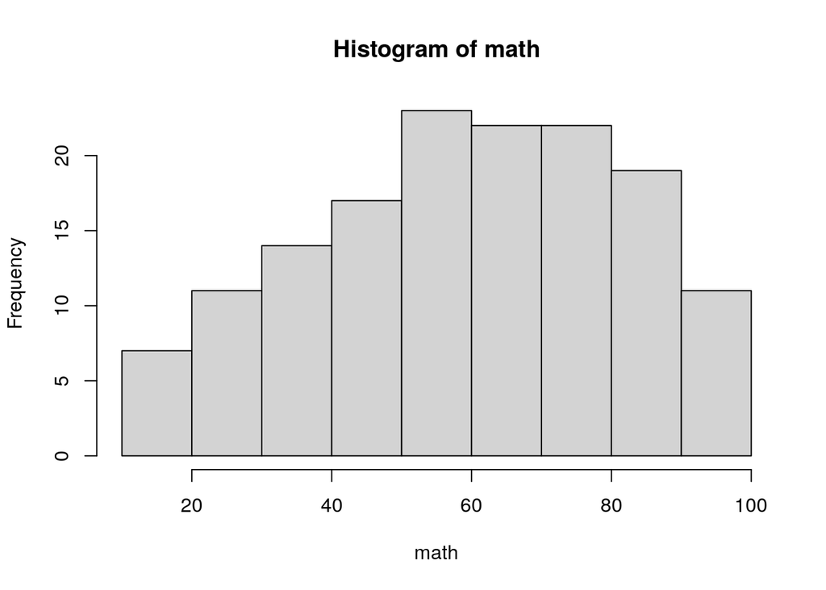

```r
hist(math)
```

- 相対度数を表示

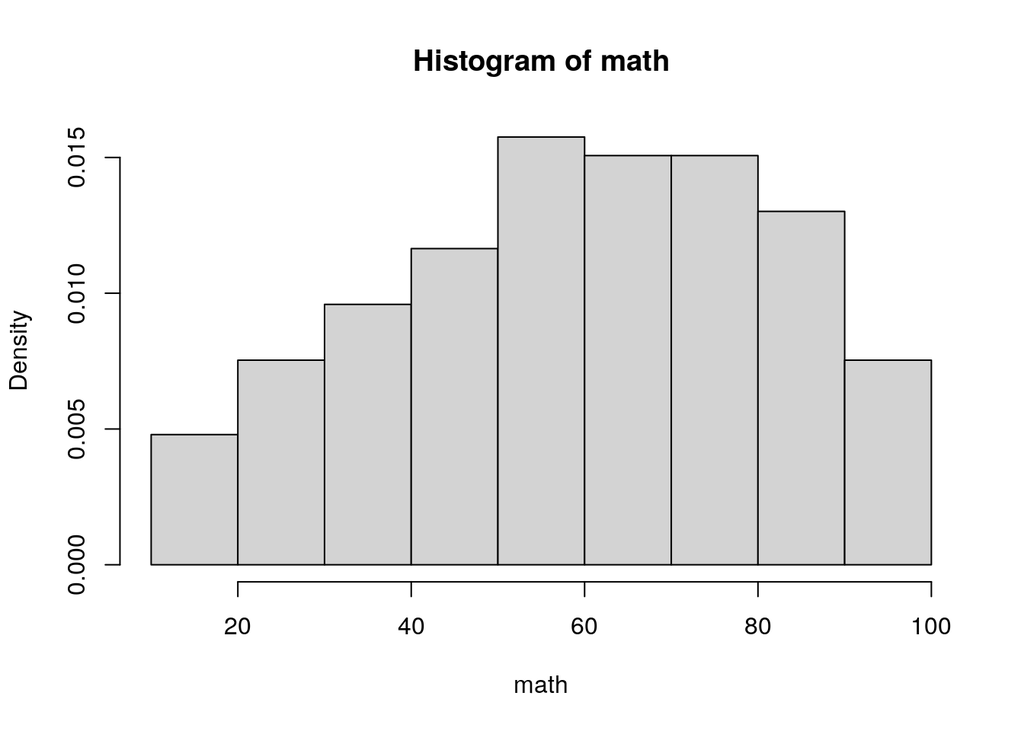

```r
hist(math, probability = TRUE)
```

### 平均

```r
mean(math)
```

```
## [1] 61.60959
```

### 不偏分散

```r
var(math)
```

```
## [1] 506.5293
```

### 標準偏差（不偏分散の平方根）

```r
sd(math)
```

```
## [1] 22.50621
```

### 標準偏差（分散の平方根）

```r
sqrt(var(math)*(length(math)-1)/length(math))
```

```
## [1] 22.429
```

### 幾何平均

```r
x <- c(1.2, 1.1, 1.05) # c()：数字を並べてベクトル化
prod(x)^(1/length(x)) # prod(x)はxの要素をすべて掛け算する関数
```

```
## [1] 1.114947
```

### 調和平均

```r
v <- c(60, 20)
1/mean(1/v) # 逆数の平均の逆数＝調和平均
```

```
## [1] 30
```

## 1.5 階級数の決め方

### スタージェスの公式

$k = 1 + \log_{2}n$

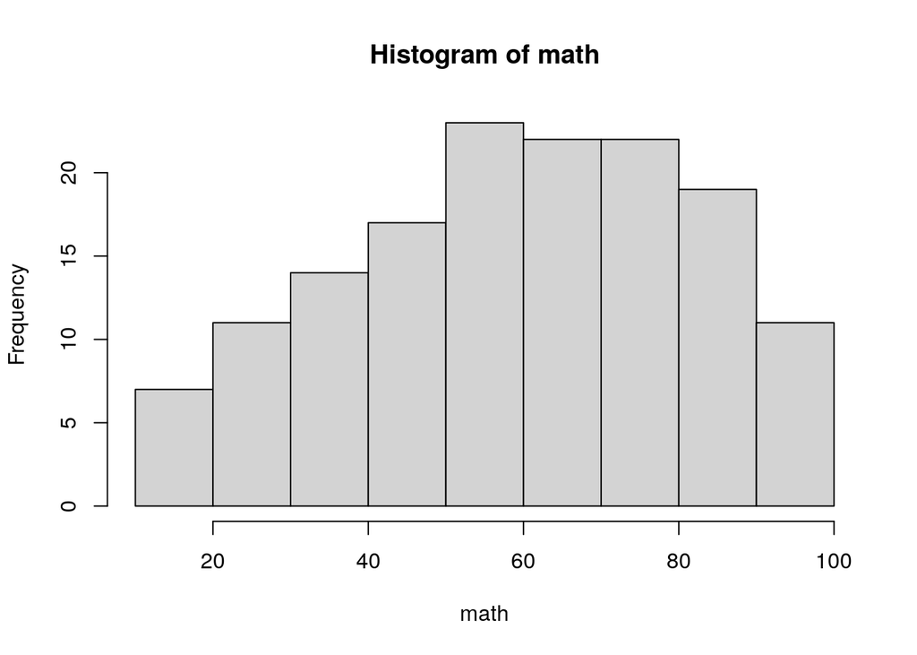

```r
hist(math, breaks = 'Sturges')
```

### 区切りの数を指定

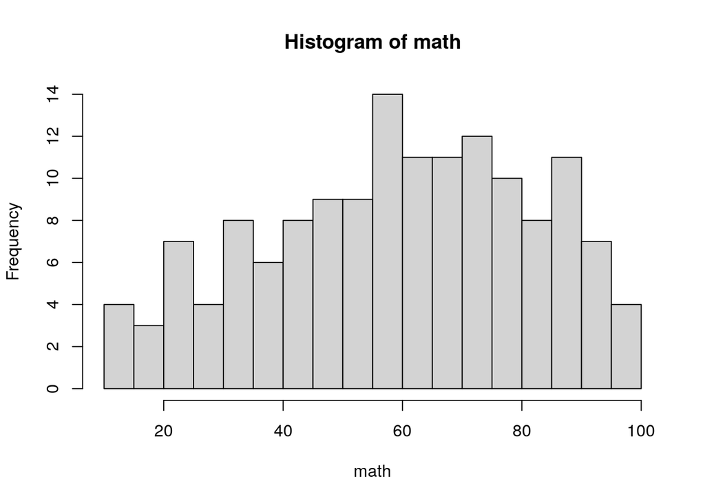

```r
hist(math, breaks = 18)
```

### 階級の幅を詳細に指定

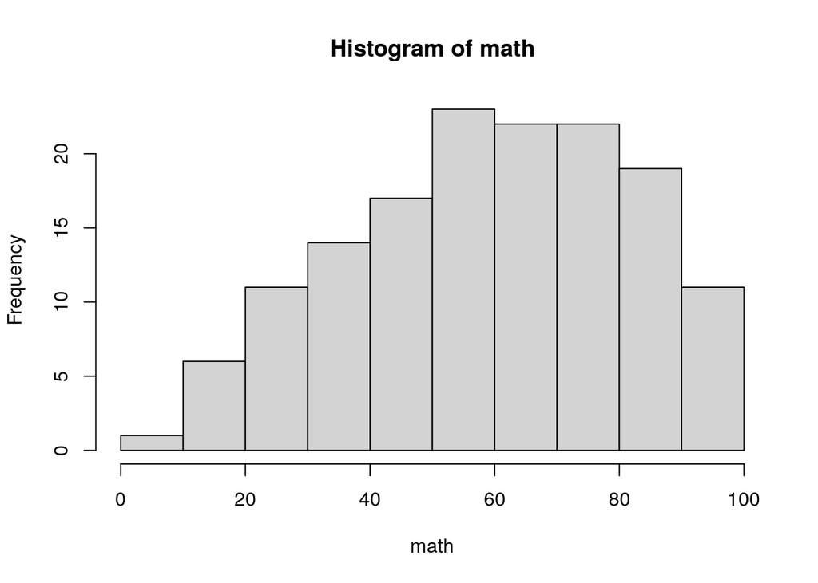

```r
hist(math, breaks = seq(0, 100, 10)) # 0から100まで10刻み
```

## 1.7 分位点と箱ひげ図

### 中央値（ｎが奇数のとき）

```r
score <- c(56, 78, 90)
median(score)
```

```
## [1] 78
```

### 中央値（ｎが偶数のとき）

```r
score <- c(56, 78, 81, 90)
median(score)
```

```
## [1] 79.5
```

### 四分位点

```r
quantile(math)
```

```
##   0%  25%  50%  75% 100%
##   10   45   65   80  100
```

### IQR：四分位偏差（第一四分位点と第三四分位点 の差Q3-Q1）

```r
IQR(math)
```

```
## [1] 35
```

### 箱ひげ図

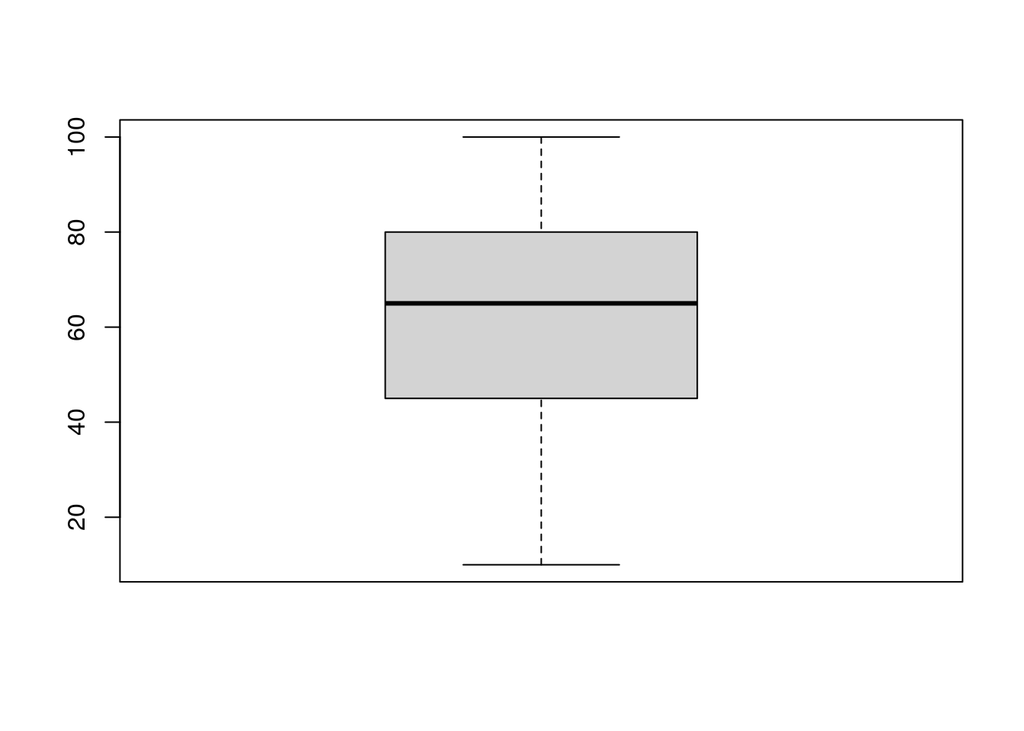

```r
boxplot(math)
```

### irisデータでboxplot

#### データの中身を確認

```r
head(iris)
```

```
##   Sepal.Length Sepal.Width Petal.Length Petal.Width Species
## 1          5.1         3.5          1.4         0.2  setosa
## 2          4.9         3.0          1.4         0.2  setosa
## 3          4.7         3.2          1.3         0.2  setosa
## 4          4.6         3.1          1.5         0.2  setosa
## 5          5.0         3.6          1.4         0.2  setosa
## 6          5.4         3.9          1.7         0.4  setosa
```

#### データの構造を表示

```r
str(iris)
```

```
## 'data.frame':    150 obs. of  5 variables:
##  $ Sepal.Length: num  5.1 4.9 4.7 4.6 5 5.4 4.6 5 4.4 4.9 ...
##  $ Sepal.Width : num  3.5 3 3.2 3.1 3.6 3.9 3.4 3.4 2.9 3.1 ...
##  $ Petal.Length: num  1.4 1.4 1.3 1.5 1.4 1.7 1.4 1.5 1.4 1.5 ...
##  $ Petal.Width : num  0.2 0.2 0.2 0.2 0.2 0.4 0.3 0.2 0.2 0.1 ...
##  $ Species     : Factor w/ 3 levels "setosa","versicolor",..: 1 1 1 1 1 1 1 1 1 1 ...
```

#### irisのいち列目から３列目までを箱ひげ図にする

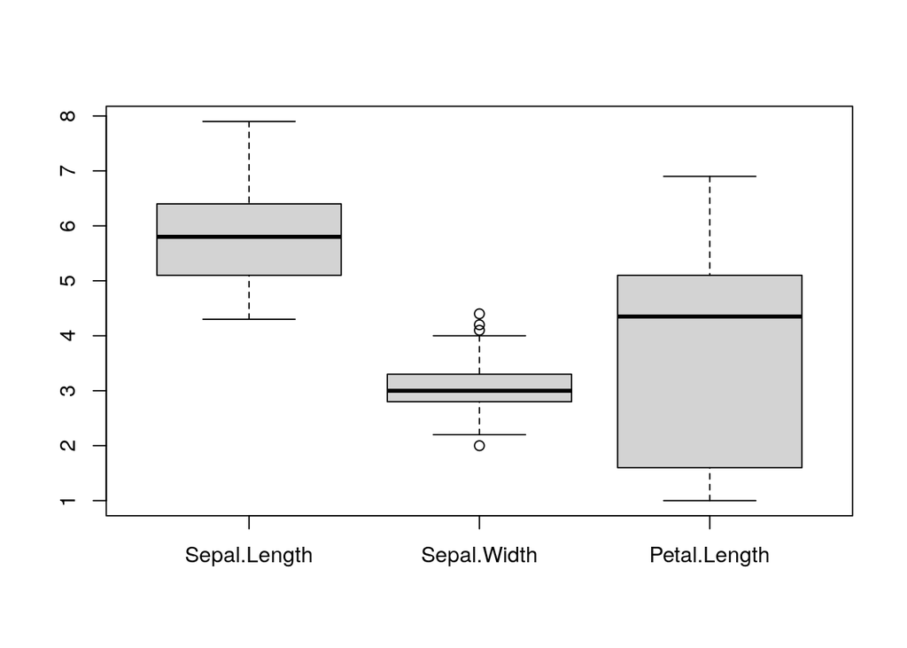

```r
boxplot(iris[, 1:3])
```

## 1.8 モード（最頻値）

### 最頻値を求める方法

- モードのパッケージ：modeest
- 以下のようにする

```r
names(which.max(table(math)))
```

```
## [1] "60"
```

- table(x)：出現回数の確認

```r
table(math)
```

```
## math
##  10  15  20  25  30  35  40  45  50  55  60  65  70  75  80  85  90  95 100
##   1   3   3   7   4   8   6   8   9   9  14  11  11  12  10   8  11   7   4
```

- which.max(x)：xの中で最大値を返すメソッド

```r
which.max(table(math))
```

```
## 60
## 11
```

- names(x)：ラベルを返す

```r
names(sampledata)
```

```
## [1] "math" "phys"
```

## 1.9 欠損値の扱いなど

```r
NA + 1
```

```
## [1] NA
```

```r
mean(NA)
```

```
## [1] NA
```

```r
NA == 1
```

```
## [1] NA
```

```r
NA != 1
```

```
## [1] NA
```

```r
a <- 1
```

```r
a == 1
```

```
## [1] TRUE
```

```r
a != 1
```

```
## [1] FALSE
```

- TRUEは1と同じ

```r
TRUE + 1
```

```
## [1] 2
```

```r
FALSE + 1
```

```
## [1] 1
```

### 欠損値はデフォルトで読み飛ばされる

```r
math_na <- read.xlsx('sampledata.xlsx', sheet = 2)
math_na
```

```
##     math_na
## 1        90
## 2        65
## 3        60
## 4        75
## 5        50
## 6        60
## 7        25
## 8        35
## 9        85
## 10      100
## 11       45
## 12       95
## 13       80
## 14       80
```

[output cut: 132 more lines]

```r
mean(math_na$math_na)
```

```
## [1] 61.60959
```

### 欠損値を追加して実験

```r
math_na2 <- c(NA, math_na$math_na)
math_na2
```

```
##   [1]  NA  90  65  60  75  50  60  25  35  85 100  45  95  80  80  95  55  55
##  [19]  65  50  65  40  85  70  65  65  15  65  75  60  75  25  65  55  40  70
##  [37]  60  60  35  75  45  60  55  75  75  90  35  20  90 100  65  15  80  80
##  [55]  85  25  10  95  45  55  80  80  40  90  95  90  70  80  25  65  30  60
##  [73]  25  35  20  70 100  50  60  50  90  65  45  35  50  85  30  50  70  85
##  [91]  85  75  80  40  60  70  80  95  50  40  25  60  35  30  45  35  70  75
## [109]  55  40 100  50  55  90  95  60  70  80  70  45  55  75  45  65  30  25
## [127]  85  90  90  60  85  20  75  70  75  50  90  60  15  90  75  70  35  95
## [145]  60  45  55
```

- 欠損値があると値がNAになる

```r
mean(math_na2)
```

```
## [1] NA
```

- 欠損値を削除するオプションを指定

```r
mean(math_na2, na.rm = TRUE)
```

```
## [1] 61.60959
```

- 欠損値を見つける

```r
head(is.na(math_na2))
```

```
## [1]  TRUE FALSE FALSE FALSE FALSE FALSE
```

## 1.10 章末問題

### 問題1-1

- 女性の変動係数

```r
5.56 / 158.23
```

```
## [1] 0.03513872
```

- 男性の変動係数

```r
5.63 / 171.58
```

```
## [1] 0.03281268
```

女性の変動係数のほうが大きいので、ばらつきも女性のほうが大きい。

### 問題1-2

```r
x <- c(2, 5, 11, 7, 9)
```

- 算術平均

```r
mean(x)
```

```
## [1] 6.8
```

- 幾何平均

```r
prod(x) ^ (1 / length(x))
```

```
## [1] 5.863361
```

- 調和平均：逆数の平均の逆数

```r
1 / mean(1/x)
```

```
## [1] 4.785251
```

- 不偏分散

```r
var(x)
```

```
## [1] 12.2
```

```r
sd(x)
```

```
## [1] 3.49285
```

### 問題1-3

```r
x <- c(34, 56, 32, 15, 49)
x
```

```
## [1] 34 56 32 15 49
```

- 平均偏差

```r
mean(abs(x - mean(x)))
```

```
## [1] 12.24
```

- 標準偏差

```r
sqrt( var(x) * (length(x) - 1) / length(x) )
```

```
## [1] 14.30245
```

### 問題1-4

```r
mean <- c(65, 59, 62)
n <- c(500, 750, 690)
sum(mean * n) / sum(n)
```

```
## [1] 61.6134
```

### 問題1-5

```r
height <- c(1.718, 1.672, 1.809)
weight <- c(74.4, 56.3, 93.2)
bmi <- weight / height^2
bmi
```

```
## [1] 25.20732 20.13890 28.47992
```

### 問題1-6

```r
x <- c(3, 4, 8, 11, 7)
```

- 不偏分散の平方根

```r
sd(x)
```

```
## [1] 3.209361
```

- 標準偏差

```r
sqrt( sd(x)^2 * ((length(x) - 1) / length(x)) )
```

```
## [1] 2.87054
```

### 問題1-7

```r
x <- c(40, 85)
z <- (x - mean(x)) / sqrt( var(x) * (length(x) - 1) / length(x) )
50 + 10 * z
```

```
## [1] 40 60
```

### 問題1-8

- rnorm(n個, 平均 ,標準偏差)で正規乱数（正規分布に従う乱数）を発生させる

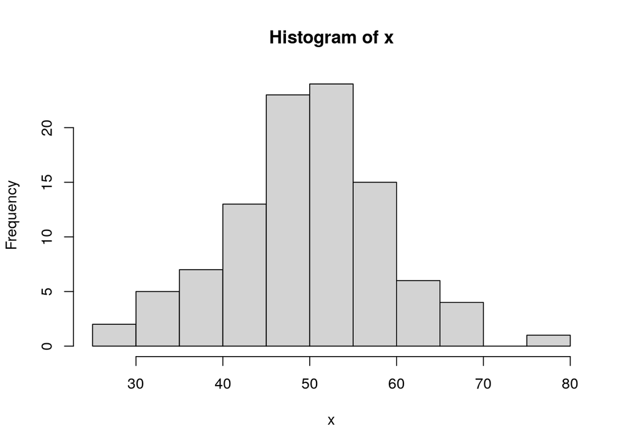

```r
x <- rnorm(100, 50, 10)
hist(x)
```

### 問題1-9

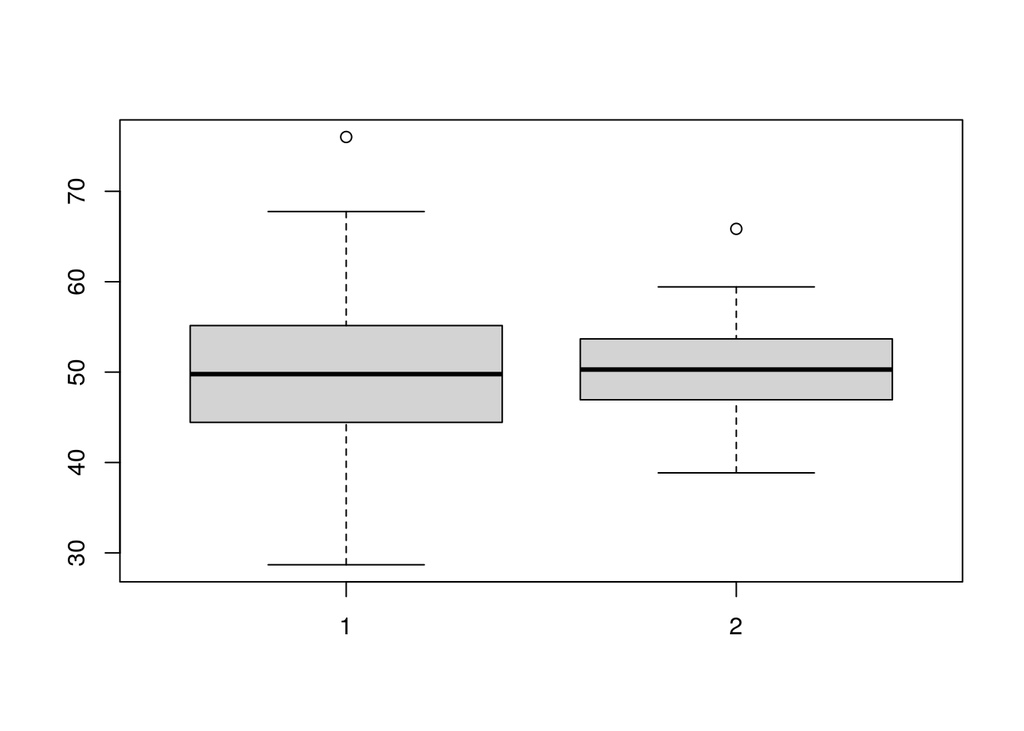

```r
y <- rnorm(100, 50, 5)
boxplot(x, y)
```

```r
IQR(x)
```

```
## [1] 10.66913
```

```r
IQR(y)
```

```
## [1] 6.653977
```

### 問題1-10

```r
x <- rnorm(5, 170, 10)
y <- c(500, x)
print('mean x y')
```

```
## [1] "mean x y"
```

```r
print(mean(x))
```

```
## [1] 168.3345
```

```r
print(mean(y))
```

```
## [1] 223.6121
```

```r
print('median x y')
```

```
## [1] "median x y"
```

```r
median(x)
```

```
## [1] 170.7897
```

```r
median(y)
```

```
## [1] 171.8024
```

### 問題1-11

- mad関数を使うと外れ値の影響を受けにくい推定ができる

```r
print('mad')
```

```
## [1] "mad"
```

```r
mad(x)
```

```
## [1] 5.812541
```

```r
mad(y)
```

```
## [1] 8.198967
```

```r
print('sd')
```

```
## [1] "sd"
```

```r
sd(x)
```

```
## [1] 6.385921
```

```r
sd(y)
```

```
## [1] 135.5223
```

### 問題1-12

```r
z <- (math - mean(math)) / sqrt( var(math) * (length(math) - 1) / length(math) )
```

- 歪度  
  マイナスだと右に、プラスだと左に偏っている

```r
mean(z^3)
```

```
## [1] -0.2749232
```

- 尖度

```r
mean(z^4)-3
```

```
## [1] -0.79586
```